# Kernel Density Estimation using R

2021-06-08

## Histograms

- Histograms provide an idea about the data distribution. Defined as:

\[ \hat{f}(x) = \frac{ \text{No. of observations within } h \text{ of } x }{n \times 2h} \\ \] or,

\[ \hat{f}(x) = \frac{1}{2nh} \sum_{i=1}^{n} I(|{X_i - x}| \le h). \]

- Narrow intervals (smaller h): histogram has a choppy appearance, large variance.
- Large intervals (larger h): histogram may lose the local feature, large bias.

## R `hist()`

- In base R’s `hist()` method, you can use the `break` argument:
- `breaks` can be one of:
1. a vector giving the breakpoints between histogram cells,
2. a function to compute the vector of breakpoints,
3. a single number giving the number of cells for the histogram,
4. a character string naming an algorithm to compute the number of cells (see ‘Details’),
5. a function to compute the number of cells.

## Sampling distribution

- By default, number of breaks is calculated by using Sturges’ formula.

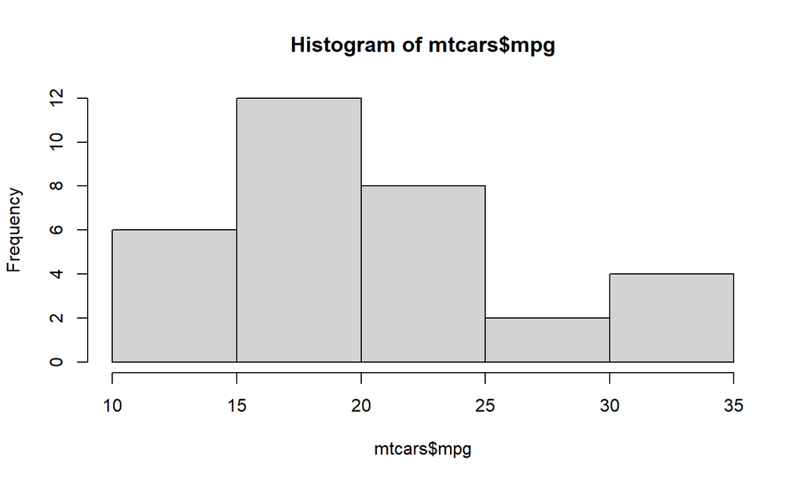

```r
data(mtcars)
hist(mtcars$mpg)
```

## Colored Histogram with Different Number of Bins

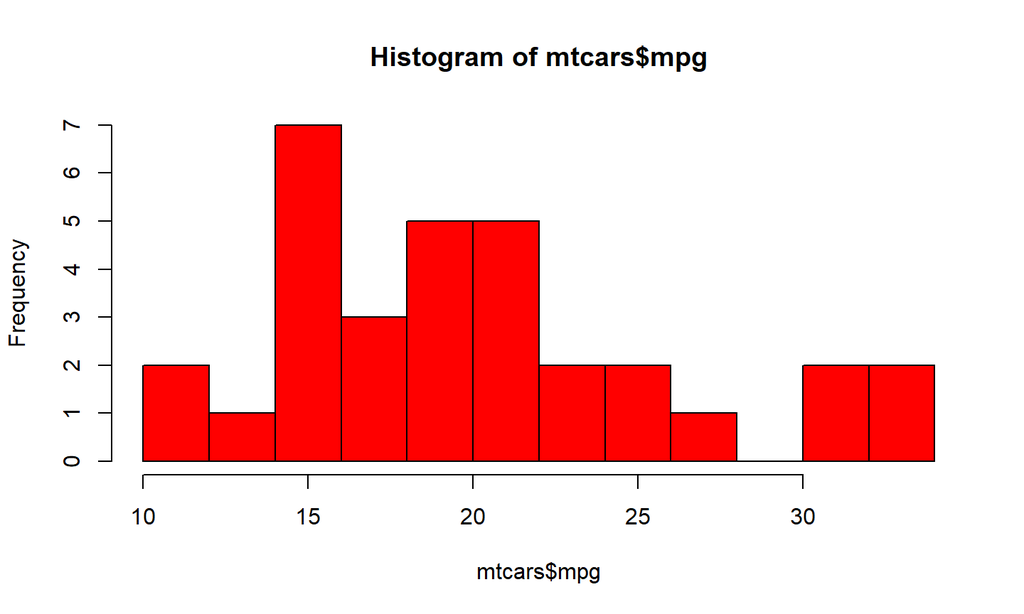

```r
hist(mtcars$mpg, breaks=12, col="red")
```

## Different h

```r
par(mfrow = c(2,2))
hist(mtcars$mpg, breaks=2, col="red")
hist(mtcars$mpg, breaks=8, col="red")
hist(mtcars$mpg, breaks=12, col="red")
hist(mtcars$mpg, breaks=20, col="red")
par(mfrow = c(1,1))
```

## Different h

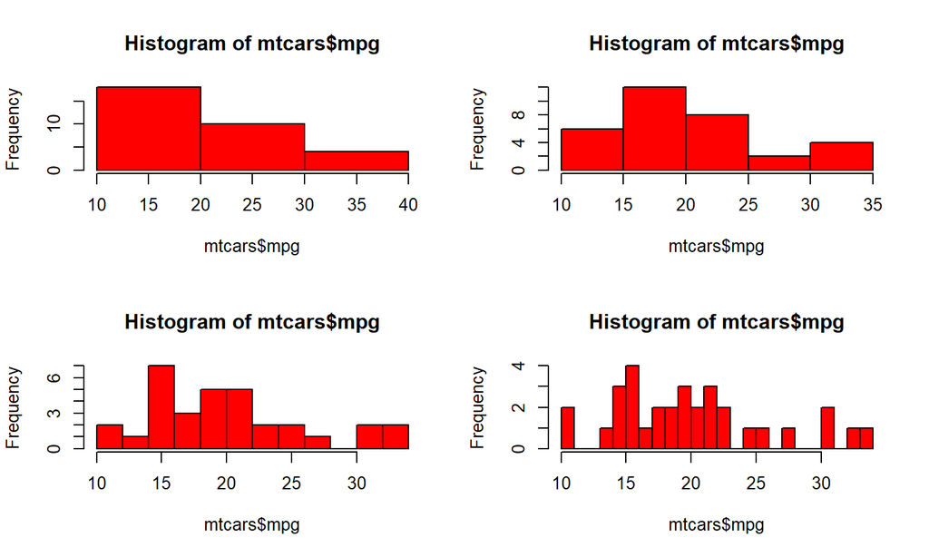

## Kernel Density Estimation

- Drawback of histogram: density estimation is piecewise constant and thus unsmooth.
- Main idea of kernel density estimation: instead of counting number of observations within \(h\) of \(x\), we take a certain weighted average of data points near \(x\) to estimate \(f(x)\).
- Kernel Density Estimate:

\[ \hat{f}(x) = \frac{1}{2nh} \sum_{i=1}^{n} K(|{X_i - x}| \le h). \] where \(K(\cdot)\) is a Kernel function.

- Choices: \(h\) bandwidth and \(K()\) the kernel.

## Kernel Density Plot

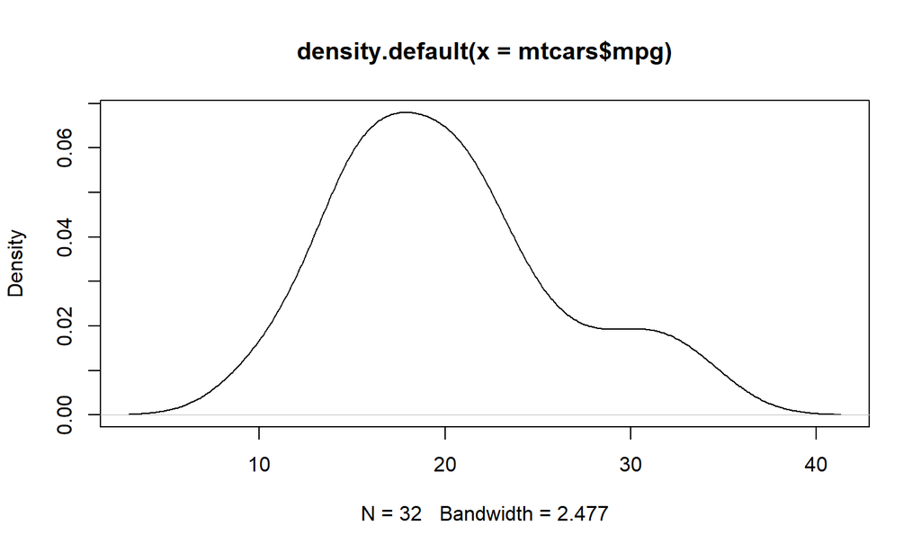

```r
d <- density(mtcars$mpg) # returns the density data
plot(d) # plots the results
```

## Kernel Density Plot with 1/3rd bandwith

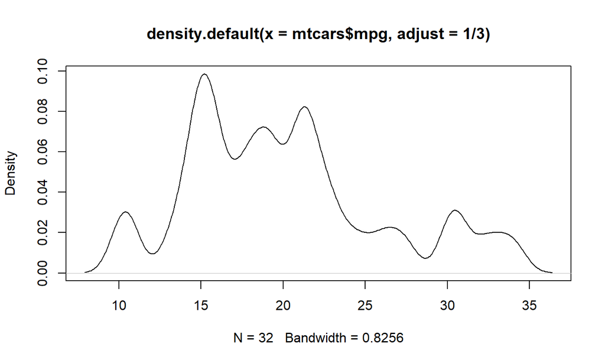

```r
d <- density(mtcars$mpg,adjust = 1/3) # returns the density data
plot(d) # plots the results
```

## Kernel Density Plot with 2x bandwith

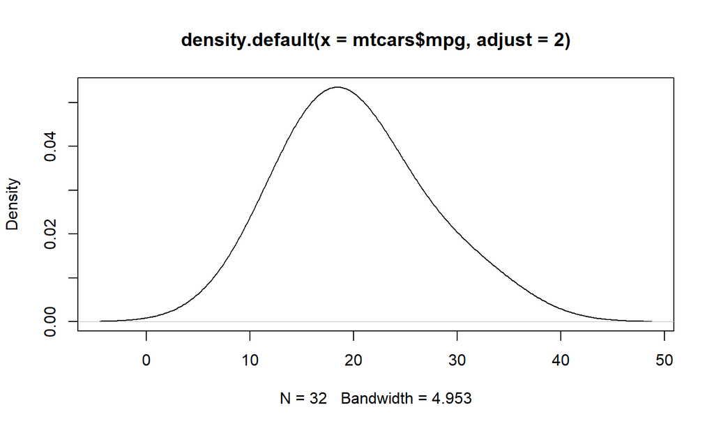

```r
d <- density(mtcars$mpg,adjust = 2) # returns the density data
plot(d) # plots the results
```

## Kernel Density Plot with a rectangular kernel

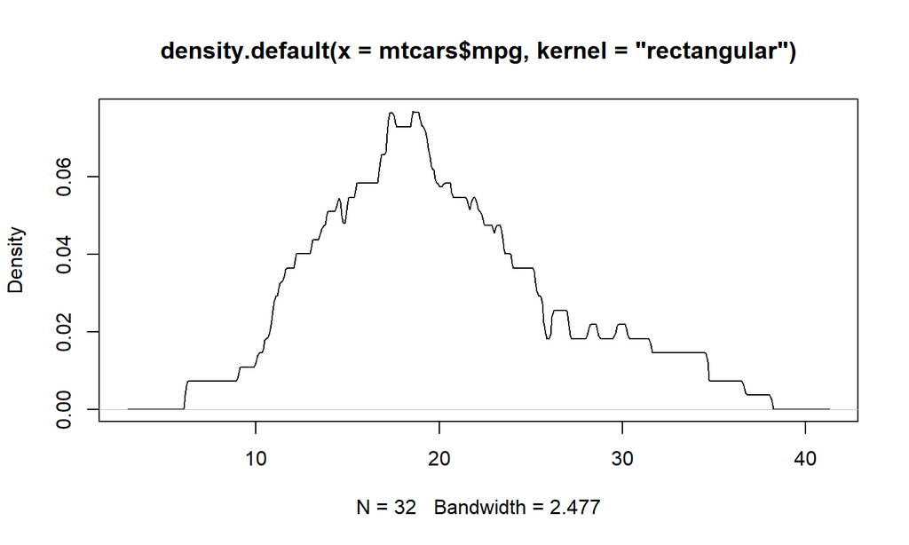

```r
d <- density(mtcars$mpg, kernel = "rectangular") # returns the density data
plot(d) # plots the results
```

## Kernel Density Plot with the Epanechnikov kernel

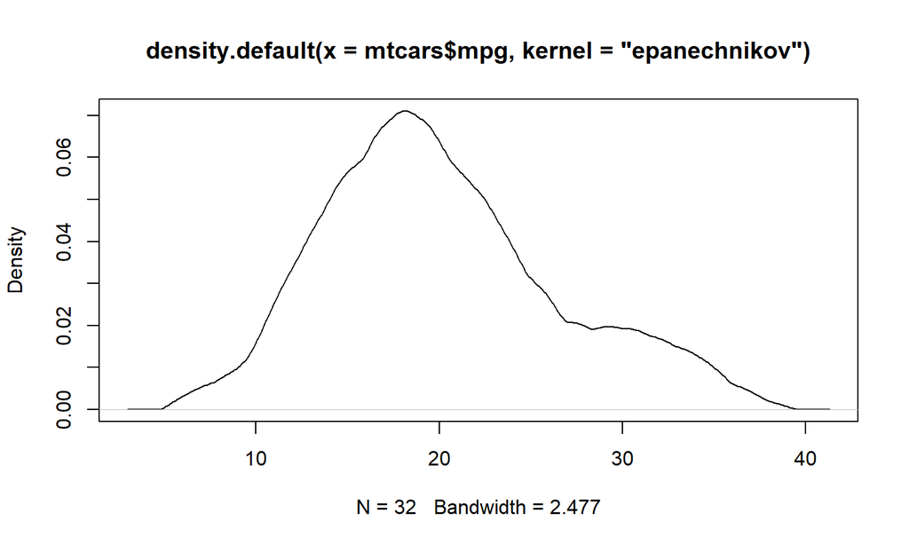

```r
d <- density(mtcars$mpg, kernel = "epanechnikov") # returns the density data
plot(d) # plots the results
```

## Faithful Geyser

```r
#take a look at the data set (the first 5 observations)
faithful[1:5,]
```

```
##   eruptions waiting
## 1     3.600      79
## 2     1.800      54
## 3     3.333      74
## 4     2.283      62
## 5     4.533      85
```

```r
duration = faithful$eruptions
n=length(duration)
#estimate the density using histogram and kernel estimation
```

## Different Kernels

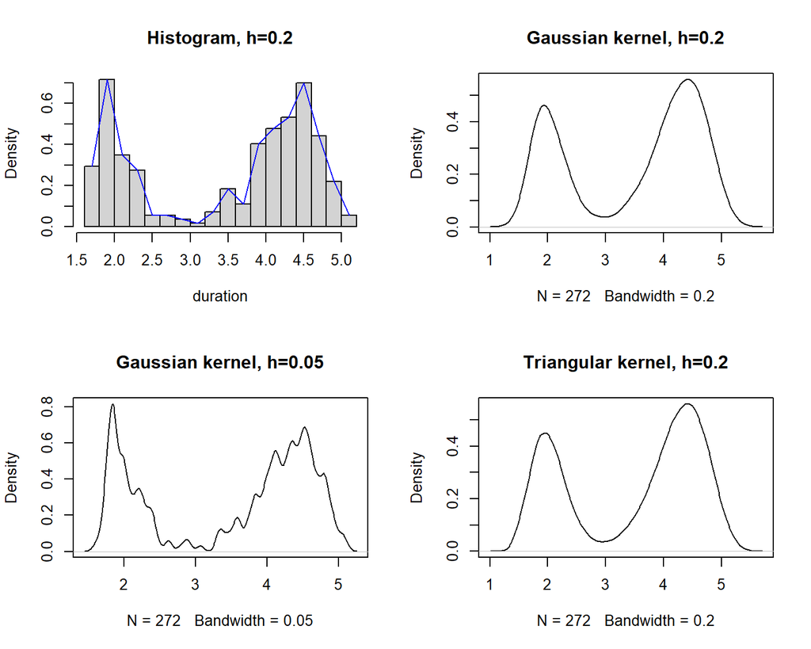